# assignment 2

### Question 3

```python
y_pred = outList[6]
trainData.insert(12, column = "y_pred", value = y_pred)
```

a). Please plot the predicted number of claims versus the observed number of claims.

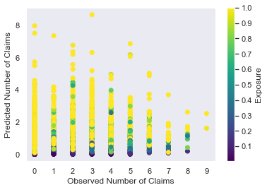

```python
plt.figure(figsize=(6,4))
sg = plt.scatter(trainData['CLM_COUNT'], trainData['y_pred'], c = e_train, marker = 'o',cmap = 'viridis')
plt.xlabel('Observed Number of Claims')
plt.ylabel('Predicted Number of Claims')
plt.xticks(range(10))
plt.grid(axis = 'both')
cbar = plt.colorbar(sg, label = 'Exposure')
cbar.set_ticks(numpy.arange(0.0, 1.1, 0.1))
plt.show()
```

b). Please plot the Deviance residuals versus the observed number of claims.

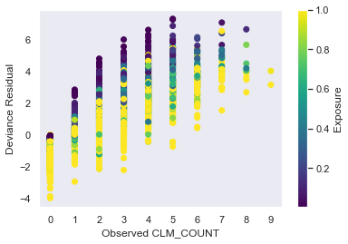

```python
dR2 = numpy.nan_to_num(y_train * numpy.log(y_train/y_pred)) - (y_train - y_pred)
devResid = numpy.where(y_train > y_pred, 1.0, -1.0) * numpy.where(dR2 > 0.0, numpy.sqrt(2.0 * dR2), 0.0)

plt.figure(figsize=(6,4))
sg = plt.scatter(trainData['CLM_COUNT'], devResid, c = e_train, marker = 'o',cmap = 'viridis')
plt.xlabel('Observed CLM_COUNT')
plt.ylabel('Deviance Residual')
plt.xticks(range(10))
plt.grid(axis = 'both')
plt.colorbar(sg, label = 'Exposure')
plt.show();
```

### Question 4

a). Please calculate the Root Mean Squared Error, the Relative Error, and the R-squared metrics.

```python
# Root Mean Squared Error
y_resid = y_train - y_pred
print('Sum of Residuals = ', numpy.sum(y_resid))

mse = numpy.sum(numpy.power(y_resid, 2)) / n_sample

rmse = numpy.sqrt(mse)
print('Root Mean Squared Error = ', rmse)

# Relative Error
relerr = mse / numpy.var(y_train, ddof = 0)
print('Relative Error = ', relerr)

sqcor = numpy.power(numpy.corrcoef(y_train, y_pred), 2)
print('Squared Correlation = ', sqcor[0,1])
```

```
Sum of Residuals =  -5.764832167187706e-09
Root Mean Squared Error =  1.5111521924451772
Relative Error =  0.9877772709997402
Squared Correlation =  0.06306347805003958
```

b). Please comment on the Final Model based on the above three metrics and the diagnostic charts in Question 3

RMSE is 1.511, which measures the size of a typical difference between a predicted target value and an observed target value.The smaller the metric, the better the model is trained, but it's actually difficult to determine what a small metric should be.

Relative Error is 0.9878, which the model performance between a saturated model and an uniformative model. Since it's very close to 1, I would say most of efforts are in vain since it's just improved a little bit from an uniformative model (relative error is 1)

Squared correlation is 0.0631, which measures the Pearson correlation between the observed target values and the predicted value. The larger the R2 metric, the better the model is trained, so we can tell the model is not trained pretty well, very close to uniformative model.

From the first scatterplot of q3 , we don't see any strong positive correlation between predicted number of claims versus the observed number of claims, meaning that the model predictions is not good at all.

From the second scatterplot of q3, we can see the deviance residual is positively correlated with observed number of claims. As the observed number of claims goes up, the deviance residual is increasing meaning the difference of likelihoods between the fitted model and the saturated model becomes bigger and bigger(worse and worse fit). Also, the exposure is always at the top of each bucket, relatively small proportion of 0 and big numbers 8 and 9, high proportion in 2-7 CLM_COUNT.